Billiani Stefano

# Analisi del mercato videoludico

Studio dei trend

Finalmente una scusa valida per chiamare ricerca la mia passione per i videogiochi

### Perché ho deciso di svolgere questo progetto?

- Ho sempre avuto passione per i videogiochi

### Perché il dominio è importante?

- I videogiochi non sono più un semplice passatempo ma un fenomeno culturale che coinvolge persone di tutte le età
- Rappresentano un mercato da centinaia di miliardi di dollari con milioni di posti di lavoro

### Quali sono le conoscenze pregresse?

- Conoscenza dei generi videoludici più popolari

### Quali sono le domande che guideranno l’analisi?

1. Quali sono i principali cambiamenti e trend nelle vendite di videogiochi nel corso degli anni?
2. I vari mercati si influenzano tra loro e quanto sono predittivi del successo globale dei videogiochi?

# Dataset e manipolazione dati

[Dataset originale su Kaggle (Rush Kirubi)](https://www.kaggle.com/datasets/rush4ratio/video-game-sales-with-ratings)

### Dati Scartati

Critic_Score

Critic_Count

User_Score

User_Count

Developer

Rating

Publisher

### Dati Considerati

Nome

Anno di rilascio

Genere

Piattaforma (unificata)

Numero di piattaforme

Vendite NA

Vendite EU

Vendite JP

Vendite altri paesi

# Analisi vendite per genere di videogioco

I prossimi grafici esplorano come le vendite variano in base al genere del gioco

1. Vendite globali dal 1985-2016
2. Vendite per genere nei vari paesi
3. Percentuale di vendite per genere
4. Diffusione temporale del genere più giocato

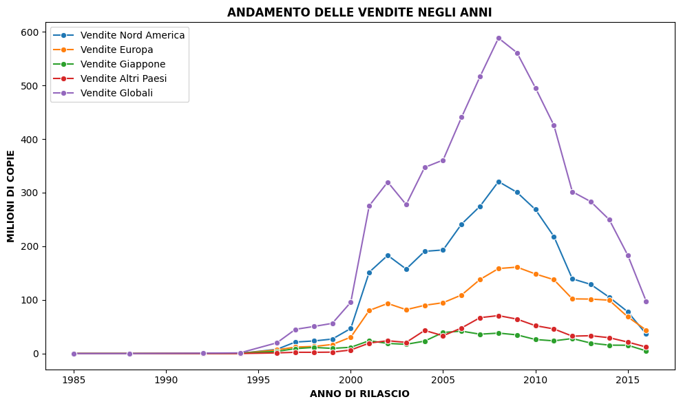

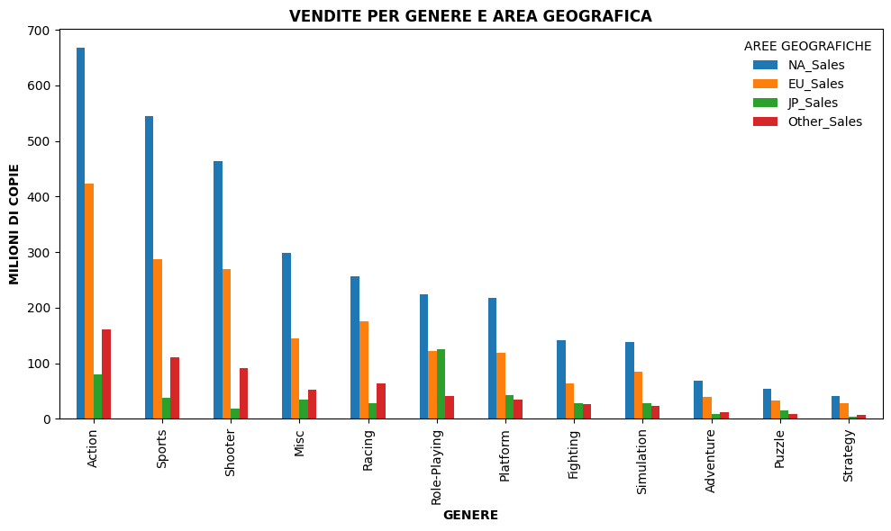

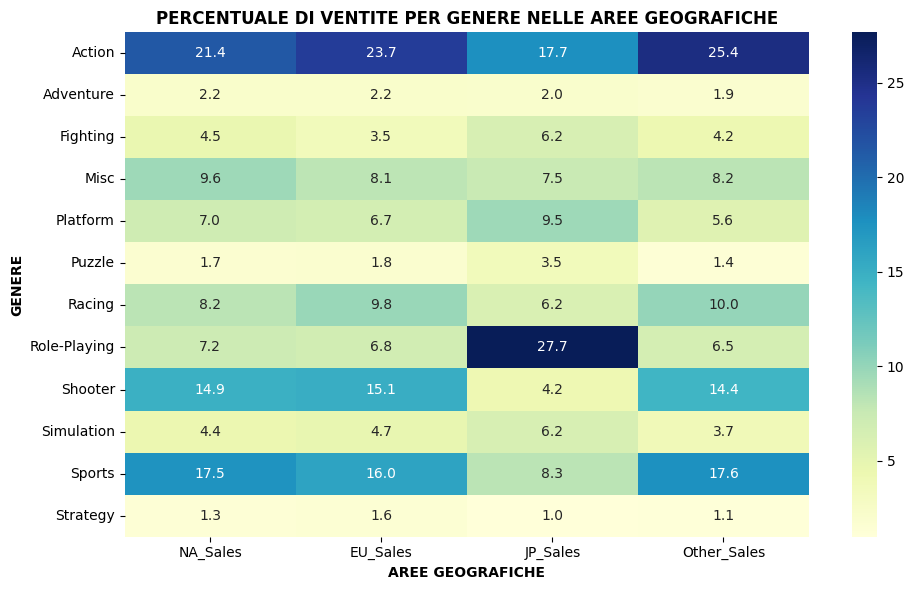

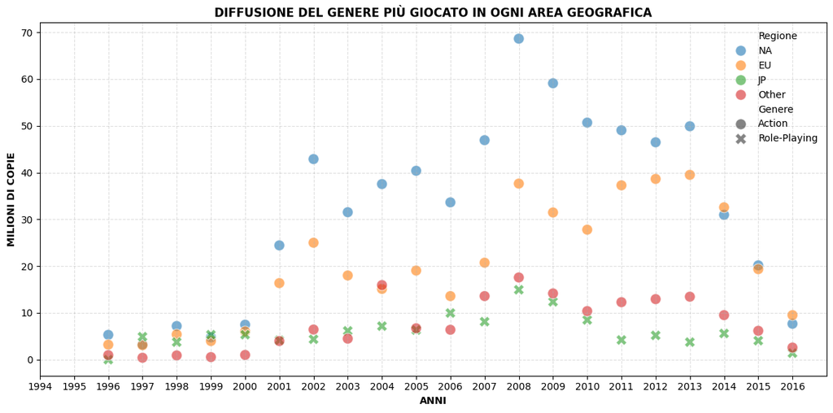

# Correlazioni tra vendite

I prossimi grafici esplorano le relazioni lineari tra vendite utilizzando il coefficiente di correlazione di Pearson

### Il Coefficiente di Pearson (r)

Misura la forza e la direzione della relazione lineare tra due variabili continue:

- r = +1: Correlazione perfetta positiva
- r = 0: Nessuna correlazione lineare
- r = -1: Correlazione perfetta negativa

### Grafici

1. Matrice di Correlazione Multi-Regionale
2. Correlazione Vendite Globali vs Nord America

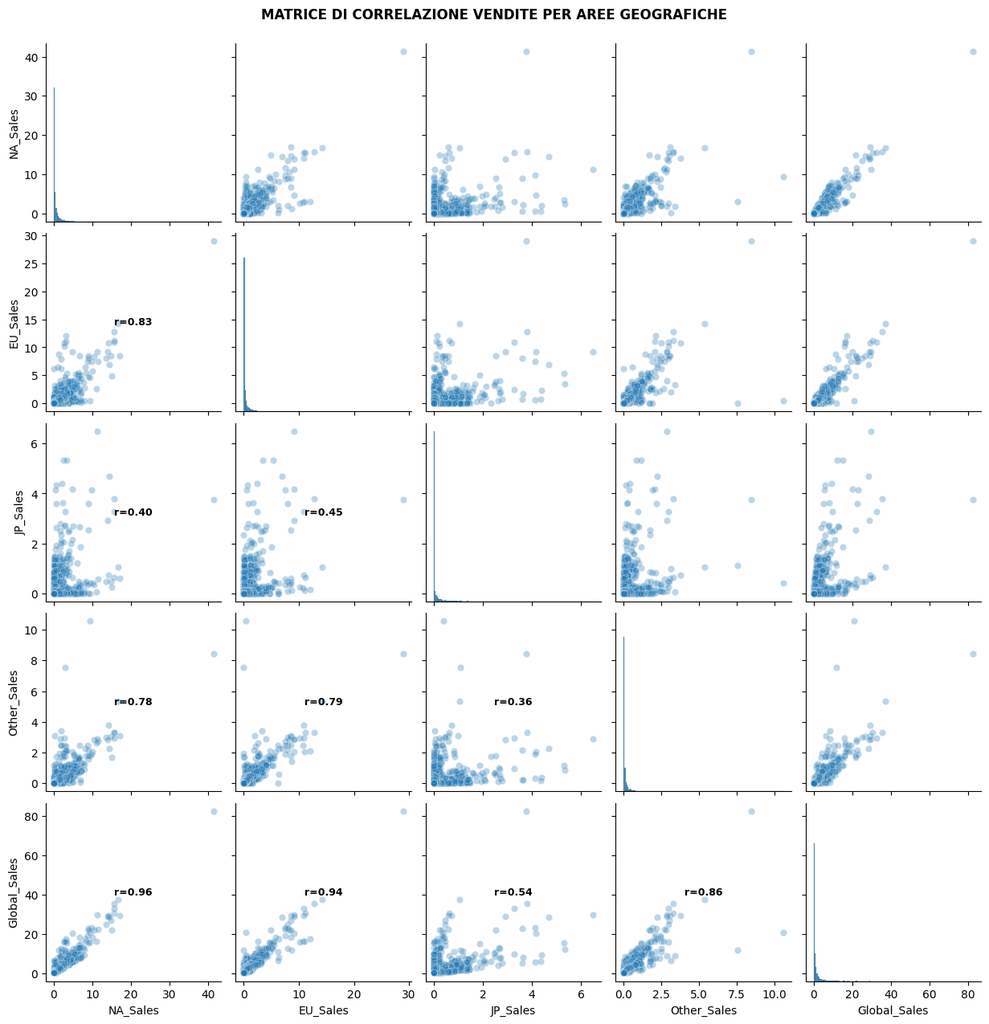

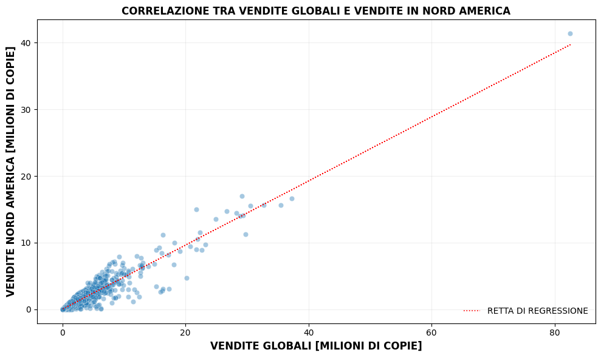

# Conclusioni

Sintesi dei risultati dall'analisi delle vendite di videogiochi

### Preferenze geografiche

**Nord America & Europa:** Action, Sports, Shooter

**Giappone:** Role-Playing dominante

### Correlazione tra mercati

Il Nord America mostra correlazione fortissima con le vendite globali **(r = 0.96)**

Il mercato nordamericano è predittivo del successo globale